# Exploratory Analysis of Daily Screen Time, Study Habits, and Academic Performance Among College Students

Samariya Yuvraj Harishbhai

2026-09-08

## Introduction

In this project, we are studying how daily screen time and study hours affect the exam performance of college students. Many students spend long hours on phones or laptops, which directly impacts their study routine and grades.

Objectives of this analysis: - Create and import a dataset of student study habits into R. - Clean and prepare the data for analysis. - Calculate basic statistical values like mean, median, variance, and standard deviation. - Visualize the data using pie charts, bar charts, and scatter plots. - Understand the relationship between screen usage and exam marks.

## 1. Data Creation and Importing

We create a dataset containing records of 10 students including their names, device type, screen hours, study hours, exam score, and performance level. We first save this as a CSV file and then read it into R using `read.csv()`.

```r
# Creating the student habits dataset
student_records <- data.frame(
  StudentID = 201:210,
  Name = c("Yuvraj", "Tanvi", "Kabir", "Sneha", "Harsh",
           "Kavya", "Varun", "Riya", "Dev", "Ishita"),
  Device_Used = c("Laptop", "Smartphone", "Tablet", "Laptop", "Smartphone",
                  "Laptop", "Smartphone", "Tablet", "Smartphone", "Laptop"),
  Daily_Screen_Time = c(3.5, 7.0, 4.5, 2.5, 8.0, 3.0, 6.5, 5.0, 7.5, 4.0),
  Daily_Study_Hours = c(5.0, 2.0, 3.5, 6.0, 1.5, 5.5, 2.5, 3.0, 1.5, 4.5),
  Exam_Score = c(88, 52, 75, 94, 45, 90, 60, 70, 48, 82),
  Performance_Level = c("High", "Low", "Average", "High", "Low",
                        "High", "Average", "Average", "Low", "High")
)

# Saving the data to a CSV file
write.csv(student_records, "student_habits_data.csv", row.names = FALSE)

# Reading the CSV file back into R
habits_df <- read.csv("student_habits_data.csv")

# Display the first few records
head(habits_df)
```

```
##   StudentID   Name Device_Used Daily_Screen_Time Daily_Study_Hours Exam_Score
## 1       201 Yuvraj      Laptop               3.5               5.0         88
## 2       202  Tanvi  Smartphone               7.0               2.0         52
## 3       203  Kabir      Tablet               4.5               3.5         75
## 4       204  Sneha      Laptop               2.5               6.0         94
## 5       205  Harsh  Smartphone               8.0               1.5         45
## 6       206  Kavya      Laptop               3.0               5.5         90
##   Performance_Level
## 1              High
## 2               Low
## 3           Average
## 4              High
## 5               Low
## 6              High
```

**Explanation:**  
We created a data frame in R with 10 student rows. Using `write.csv()`, we exported the data to our working folder, and then imported it back using `read.csv()`. `head()` is used to inspect the imported rows.

## 2. Data Preprocessing and Cleaning

Before doing calculations, we check the structure of our variables, check if there are any missing values, and convert text columns into factors.

```r
# Checking data structure
str(habits_df)
```

```
## 'data.frame':    10 obs. of  7 variables:
##  $ StudentID        : int  201 202 203 204 205 206 207 208 209 210
##  $ Name             : chr  "Yuvraj" "Tanvi" "Kabir" "Sneha" ...
##  $ Device_Used      : chr  "Laptop" "Smartphone" "Tablet" "Laptop" ...
##  $ Daily_Screen_Time: num  3.5 7 4.5 2.5 8 3 6.5 5 7.5 4
##  $ Daily_Study_Hours: num  5 2 3.5 6 1.5 5.5 2.5 3 1.5 4.5
##  $ Exam_Score       : int  88 52 75 94 45 90 60 70 48 82
##  $ Performance_Level: chr  "High" "Low" "Average" "High" ...
```

```r
# Checking for missing values
colSums(is.na(habits_df))
```

```
##         StudentID              Name       Device_Used Daily_Screen_Time
##                 0                 0                 0                 0
## Daily_Study_Hours        Exam_Score Performance_Level
##                 0                 0                 0
```

```r
# Converting categorical columns to factor
habits_df$Device_Used <- as.factor(habits_df$Device_Used)
habits_df$Performance_Level <- factor(
  habits_df$Performance_Level,
  levels = c("Low", "Average", "High")
)

# Checking summary of factors
summary(habits_df[, c("Device_Used", "Performance_Level")])
```

```
##      Device_Used Performance_Level
##  Laptop    :4    Low    :3
##  Smartphone:4    Average:3
##  Tablet    :2    High   :4
```

**Explanation:**  
`str()` shows the data type of each column. `colSums(is.na())` verifies whether any value is missing (all are 0 here). `as.factor()` and `factor()` convert character data into category levels so that R can group them easily.

## 3. Statistical Exploration

Here we calculate descriptive statistics for the exam scores, study hours, and daily screen time using standard functions.

```r
# Mean and Median of Exam Score
mean(habits_df$Exam_Score)
```

```
## [1] 70.4
```

```r
median(habits_df$Exam_Score)
```

```
## [1] 72.5
```

```r
# Variance and Standard Deviation of Exam Score
var(habits_df$Exam_Score)
```

```
## [1] 333.3778
```

```r
sd(habits_df$Exam_Score)
```

```
## [1] 18.25864
```

```r
# Mean and SD for Screen Time and Study Hours
mean(habits_df$Daily_Screen_Time)
```

```
## [1] 5.15
```

```r
sd(habits_df$Daily_Screen_Time)
```

```
## [1] 1.972731
```

```r
mean(habits_df$Daily_Study_Hours)
```

```
## [1] 3.5
```

```r
sd(habits_df$Daily_Study_Hours)
```

```
## [1] 1.666667
```

**Explanation:**  
We used `mean()` to find the central average mark and `median()` for the middle value. `var()` and `sd()` are calculated to see the spread and variability in exam marks and study patterns.

## 4. Graph and Plot Creation

### A. Device Usage and Performance Distribution (Pie Charts)

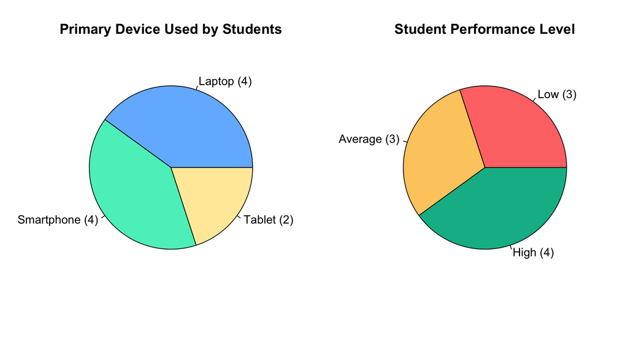

```r
par(mfrow = c(1, 2))

# Pie Chart 1: Primary Device
device_counts <- table(habits_df$Device_Used)
pie(
  device_counts,
  main = "Primary Device Used by Students",
  col = c("#74b9ff", "#55efc4", "#ffeaa7"),
  labels = paste0(names(device_counts), " (", device_counts, ")")
)

# Pie Chart 2: Performance Levels
perf_counts <- table(habits_df$Performance_Level)
pie(
  perf_counts,
  main = "Student Performance Level",
  col = c("#ff7675", "#fdcb6e", "#00b894"),
  labels = paste0(names(perf_counts), " (", perf_counts, ")")
)
```

### B. Daily Screen Time and Exam Scores (Bar Charts)

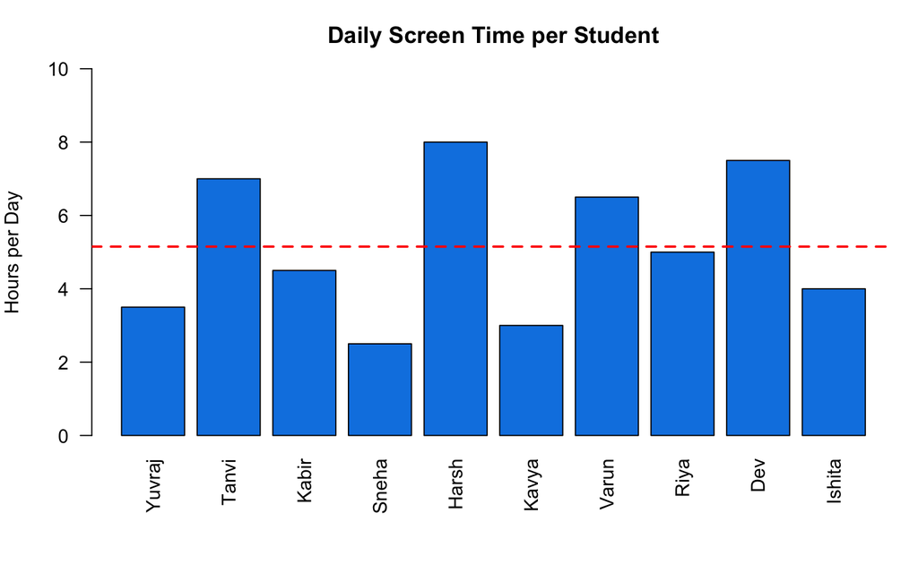

```r
par(mfrow = c(1, 1), mar = c(6, 4, 3, 1))

# Bar Chart 1: Screen Time per Student
barplot(
  habits_df$Daily_Screen_Time,
  names.arg = habits_df$Name,
  main = "Daily Screen Time per Student",
  ylab = "Hours per Day",
  col = "#0984e3",
  las = 2,
  ylim = c(0, 10)
)
abline(h = mean(habits_df$Daily_Screen_Time), col = "red", lty = 2, lwd = 2)
```

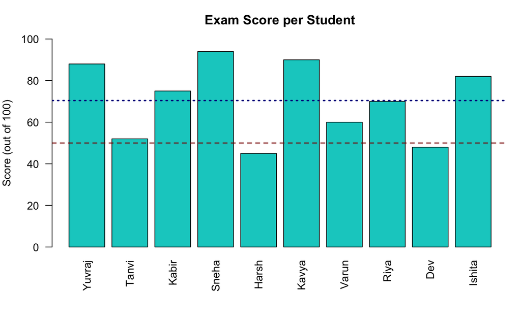

```r
# Bar Chart 2: Exam Score per Student
barplot(
  habits_df$Exam_Score,
  names.arg = habits_df$Name,
  main = "Exam Score per Student",
  ylab = "Score (out of 100)",
  col = "#00cec9",
  las = 2,
  ylim = c(0, 100)
)
abline(h = 50, col = "darkred", lty = 2, lwd = 1.5) # Pass line
abline(h = mean(habits_df$Exam_Score), col = "darkblue", lty = 3, lwd = 2) # Average line
```

### C. Relationship Between Study Hours and Exam Score (Scatter Plot)

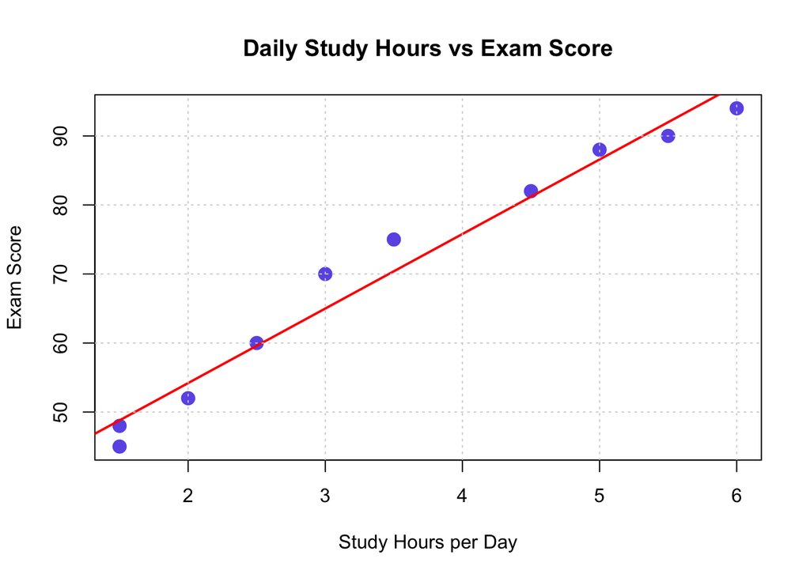

```r
plot(
  habits_df$Daily_Study_Hours,
  habits_df$Exam_Score,
  main = "Daily Study Hours vs Exam Score",
  xlab = "Study Hours per Day",
  ylab = "Exam Score",
  pch = 19,
  col = "#6c5ce7",
  cex = 1.5
)
abline(lm(Exam_Score ~ Daily_Study_Hours, data = habits_df), col = "red", lwd = 2)
grid()
```

**Explanation:**  
- `pie()` shows the breakdown of devices and performance categories. - `barplot()` compares each student’s screen hours and exam marks, with reference lines added via `abline()`. - `plot()` with `lm()` displays how marks increase as study hours increase.

## 6. Findings and Conclusion

- **Finding 1:** High non-academic screen time is associated with lower exam marks.
- **Finding 2:** 4 to 6 hours of daily focused study is consistent among top-performing students.
- **Conclusion:** Students should manage and reduce unnecessary phone or laptop time and allocate fixed hours for self-study to improve their academic results.